# A First Step in Understanding Logistic Regression Applications in Rare Events

Author

Steven Wong

Published

December 7, 2025

## Introduction

Logistic regression is one of the most widely used statistical models for binary outcomes, especially in clinical and public-health research. In this project we apply logistic regression to a Kaggle stroke dataset to explore how well common risk factors predict stroke, and to compare three related models:

- Standard logistic regression
- Firth’s penalized logistic regression
- FLIC (Firth with intercept correction)

We also briefly review the history of the logistic function, its role in odds and log-odds modelling, and why it is a natural choice for stroke prediction.

### Brief background

The logistic function originated in population-growth modelling. Verhulst proposed the differential equation which led to the logistic function

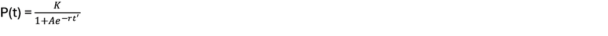

an S-shaped function bounded between 0 and 1.

Over time, the logistic function was adopted in toxicology, psychology, econometrics, and then generalized into what we now call *logistic regression*: a regression model that links predictors to the *log-odds* of a binary response. With modern computing and software, logistic regression has become a standard tool in medicine, finance, and social science.

### Logistic regression in stroke research (examples)

Many stroke-related studies have used logistic regression to:

- Identify inflammatory markers associated with acute ischemic stroke outcomes
- Rank vascular risk factors for improved risk calculators
- Study how comorbidities such as hyperlipidemia or diabetes influence stroke severity and mortality
- Evaluate lifestyle factors (e.g., smoking, diet, physical activity) in large observational cohorts

These applications motivate our choice of logistic regression for the Kaggle stroke dataset and provide clinical context for interpreting model coefficients and predictive performance.

## Method

### Logistic function and logistic regression

The general logistic function can be written as

where:

- (L) is the limiting (maximum) value
- (k) controls the steepness
- (x_0) is the midpoint (inflection point)

A common *standard* logistic form sets (L=1), yielding a function that maps any real-valued input to a probability in (0, 1).

[figure not shown]

Logistic regression uses this logistic function as a *link* between predictors and the outcome probability. For a binary outcome (Y ) and predictor vector (X), we model

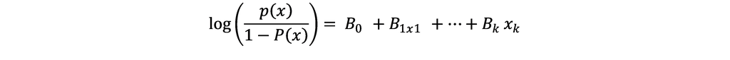

### Logistic function example

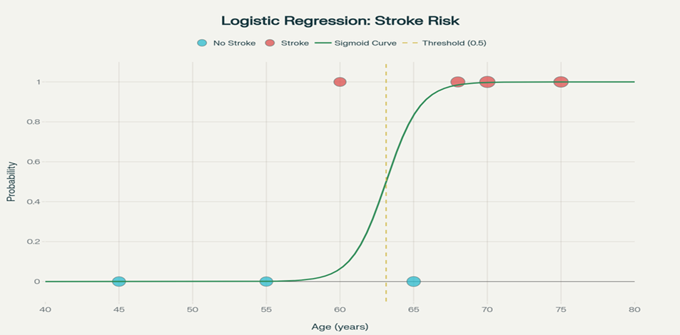

In the stroke context, each point on the curve represents a patient with certain risk-factor values (age, blood pressure, glucose, etc.), and the logistic curve maps those risk factors to an estimated stroke probability. A threshold (often 0.5, but not always optimal) converts this probability into a predicted class (“stroke” vs “no stroke”).

## Data and analysis

### Data acquisition

We use the public *stroke.csv* dataset from Kaggle, which includes variables such as:

- `age`
- `gender`
- `hypertension`
- `heart_disease`
- `ever_married`
- `work_type`
- `Residence_type`
- `avg_glucose_level`
- `bmi`
- `smoking_status`
- `stroke` (0 = no stroke, 1 = stroke)

### Data cleaning

We recode missing or ambiguous values, convert appropriate columns to factors, and drop the `id` column. BMI and glucose are converted to numeric and rounded for convenience.

### Descriptive statistics

Descriptive Statistics

| Mean_Age | Range_Age | SD_Age | Mean_BMI | Range_BMI | SD_BMI | Mean_AvgGlucoseLvl | Range_AvgGlucoseLvl | SD_AvgGlucoseLvl |
| --- | --- | --- | --- | --- | --- | --- | --- | --- |
| 49.38029 | 13 - 82 | 18.31223 | 30.43714 | 11.5 - 92 | 7.249985 | 108.4547 | 55.12 - 271.74 | 47.91804 |

[figure not shown]

### Descriptive Statistics Charts

Descriptive Statistics

| Mean_Age | Range_Age | SD_Age | Mean_BMI | Range_BMI | SD_BMI | Mean_AvgGlucoseLvl | Range_AvgGlucoseLvl | SD_AvgGlucoseLvl |
| --- | --- | --- | --- | --- | --- | --- | --- | --- |
| 49.38029 | 13 - 82 | 18.31223 | 30.43714 | 11.5 - 92 | 7.249985 | 108.4547 | 55.12 - 271.74 | 47.91804 |

```
 [1] "gender"            "age"               "hypertension"
 [4] "heart_disease"     "ever_married"      "work_type"
 [7] "Residence_type"    "avg_glucose_level" "bmi"
[10] "smoking_status"    "stroke"
```

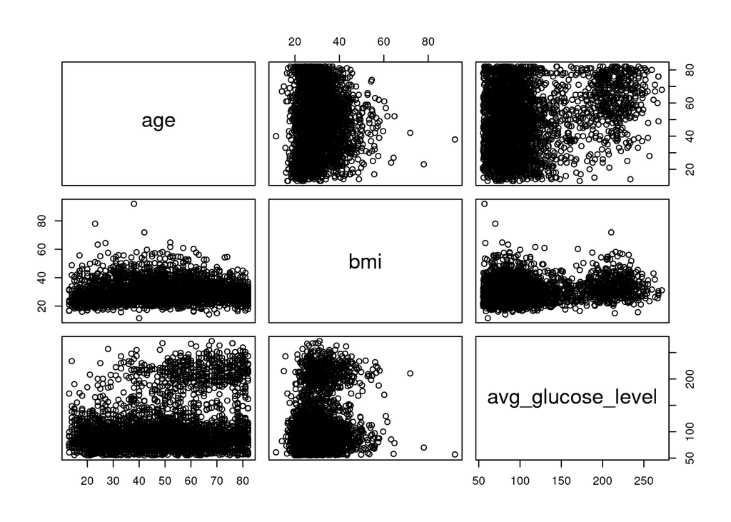

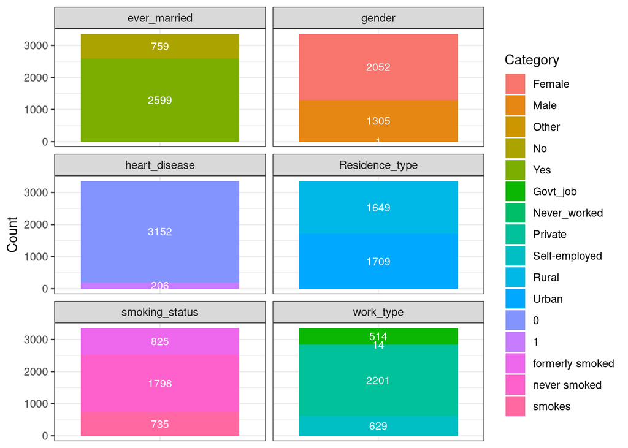

## Logistic regression assumptions

We check four standard assumptions:

1. The outcome is binary.
2. There is an approximately linear relationship between continuous predictors and the logit of the outcome.
3. There are no excessively influential outliers.
4. There is no severe multicollinearity among predictors.

```
[1] 1 0
Levels: 0 1
```

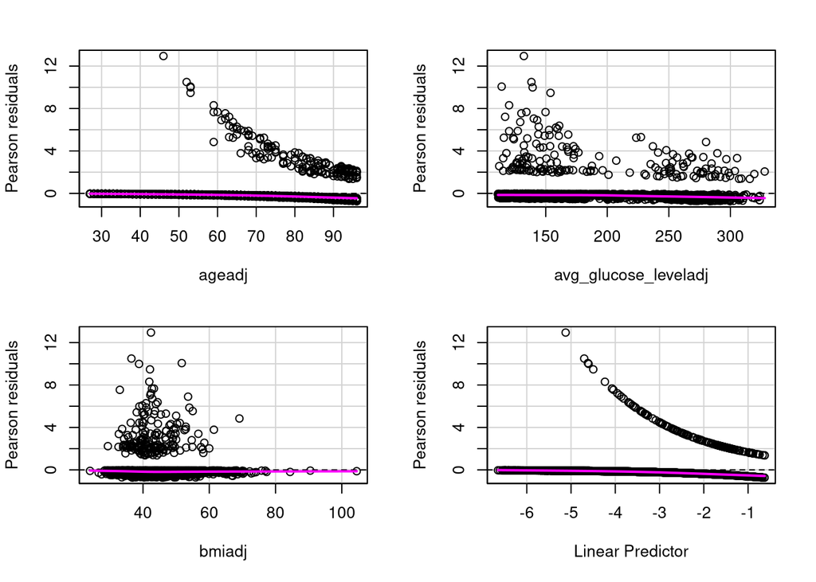

```
                     Test stat Pr(>|Test stat|)
ageadj                  2.0002           0.1573
avg_glucose_leveladj    0.0071           0.9327
bmiadj                  0.3553           0.5511
```

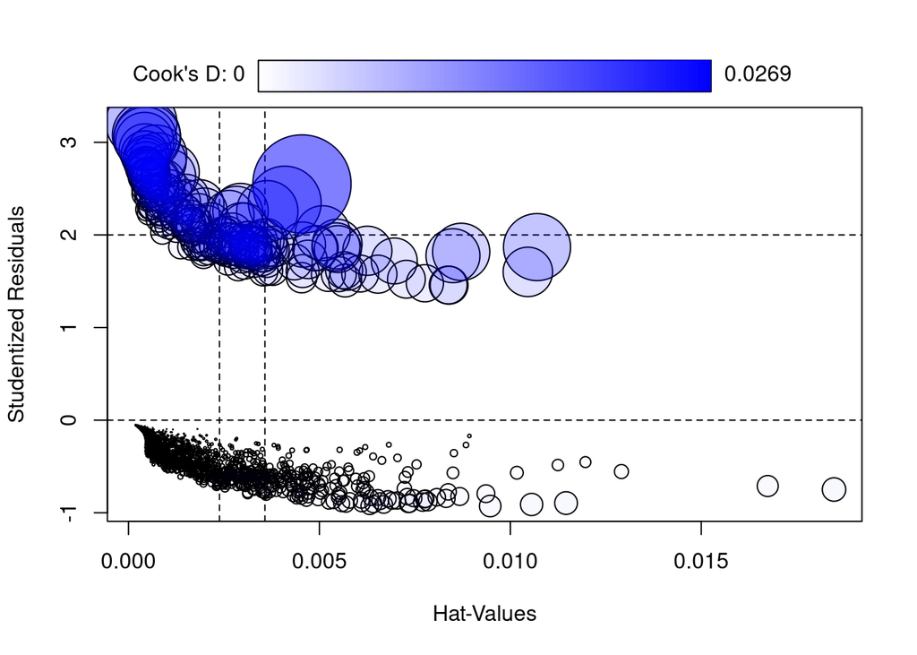

Key Regression Diagnostics

| Check | Value |
| --- | --- |
| Max VIF (multicollinearity) | 1.1 |
| Influential cases (Cook’s D > 0.5) | 0.0 |

The diagnostics suggest that:

- The outcome is appropriately binary.
- Plots of residuals vs. predictors do not indicate strong non-linearity.
- There are no highly influential points with Cook’s distance > 0.5.
- VIF values are low, indicating no serious multicollinearity.

Thus, logistic regression is a reasonable modelling choice for this dataset.

## Three logistic regression models

Due to the relatively low prevalence of stroke in the dataset (about 5–6%), we consider three models:

1. **Baseline logistic regression**
2. **Firth’s penalized logistic regression** (reduces small-sample and separation bias)
3. **FLIC** (Firth with intercept correction, aligning predicted event rate with observed prevalence)

### Confusion matrix and performance measures

We evaluate the models using:

- Confusion matrices (at a 0.5 threshold)
- Precision, recall, F1 score
- AUC (area under the ROC curve)
- Youden’s J statistic (for optimal threshold selection)
- Calibration Plots

Logistic Regression Model Metrics Comparison

|  | Model | Precision | Recall | F1 | AUC | youden |
| --- | --- | --- | --- | --- | --- | --- |
| Pos Pred Value…1 | Baseline LR | 0.5 | 0.006 | 0.011 | 0.830 | 1.523 |
| Pos Pred Value…2 | Firth LR | 0.5 | 0.006 | 0.011 | 0.829 | 1.522 |
| Pos Pred Value…3 | FLIC LR | 0.5 | 0.006 | 0.011 | 0.829 | 1.522 |

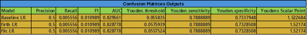

### ROC curves and Youden’s J

[figure not shown]

### Confusion matrix plots

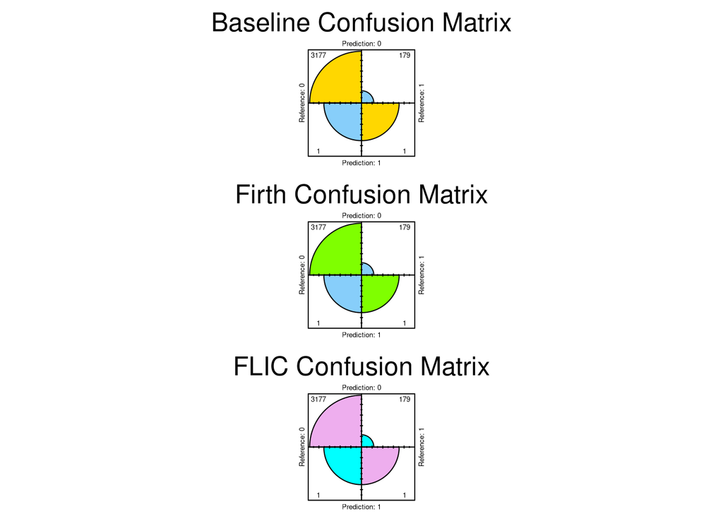

### Calibration Plots

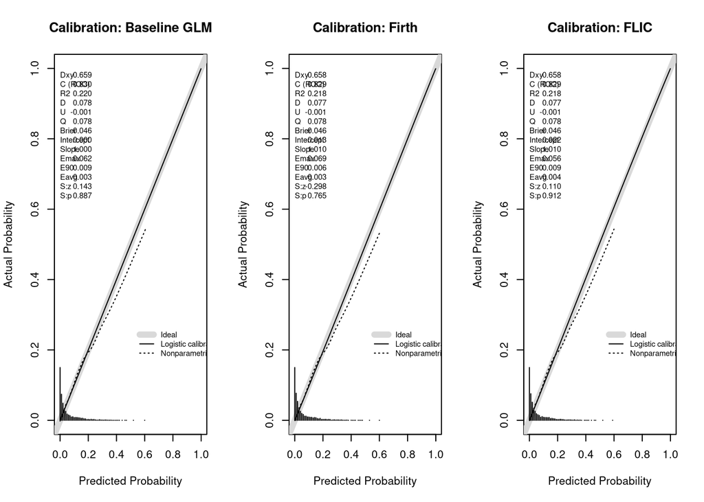

## Future directions and conclusion

Possible future directions include:

- Exploring alternative models (e.g., random forests, gradient boosting, neural networks)
- Using resampling or SMOTE to adjust class imbalance and comparing resulting performance
- Performing external validation on a different stroke dataset that have different predictors that may interact, such as Type Diabetes stroke, age and years diagnosed.

Overall, logistic regression remains an interpretable and clinically useful method for stroke risk prediction in this setting.

## References

Allison P. 2012. Logistical Regression For Rare Events. Statistical Horizons.https://statisticalhorizons.com/logistic-regression-for-rare-events/

Bailly A, Blanc C, Francis E, Guillotin T, Jamal F, Wakim B, Roy P. 2022. Effects of dataset size and interactions on the prediction performance of logistic regression and deep learning models. *Computer Methods and Programs in Biomedicine* 213:106504. https://doi.org/10.1016/j.cmpb.2021.106504

Cramer JS. 2002. The origins of logistic regression. *Tinbergen Institute Discussion Paper* TI 2002-119/4:1–14.

Cuadrado-Godia E, Jamthikar DA, Gupta D, Khanna NN, Araki T, Maniruzzaman M, Saba L, Nicolaides A, Sharma A, Omerzu T, Suri SH, Gupta AM, Mavrogeni S, Turk M, Laird RJ, Protogerou A, Sfikakis P, Kitas DG, Viswanathan V, Suri SJ. 2019. Ranking stroke and cardiovascular risk factors for an optimal calculator design: logistic regression approach. *Computers in Biology and Medicine* 108:182–195. https://doi.org/10.1016/j.compbiomed.2019.03.020

Eliason LE, MacDougall H, Peterson L. 2022. Understanding the aggressive practices of nonprofit hospitals in pursuit of patient debt. *Health & Social Work* 47(1):36–44. https://academic.oup.com/hsw/article/47/1/36/6459097

Hadjira LC, Badreddine A, Sabri A. 2025. Socio-demographic determinants of women’s entrepreneurship: a binary logistic regression analysis. *Business Ethics and Leadership* 9(2):55–64. http://doi.org/10.61093/bel.9(2).55-64.2025

Hua Y, Stead ST, George A, Ganti L. 2025. Clinical risk prediction with logistic regression: best practices, validation techniques, and applications in medical research. *Academic Surgery and Medicine* (online). https://doi.org/10.62186/001c.131964

King MD, Hatcher SS, Bride B. 2015. An exploration of risk factors associated with dating violence: examining the predictability of adolescent female dating violence perpetration. *Journal of Human Behavior in the Social Environment* 25:907–922. https://doi.org/10.1080/10911359.2015.1040907

Liu H, Li R, Wang L, Zhu L, Zhu X, Zhou Q, Yang Z, Liu H. 2025. Analyzing the correlation between acute ischemic stroke and triglyceride-glucose index based on ordered logistic regression. *Frontiers in Neurology* 16:1500572. https://doi.org/10.3389/fneur.2025.1500572

Puhr R, Heinze G, Nold M, Luisa L, Geroldinger A. 2017. Firth’s logistic regression with rare events: accurate effect estimates and predictions? *Statistics in Medicine* 36:2302-2317. https://doi.org/10.10002/sim.7273

Shigematsu K, Watanabe Y, Nakano H, Kyoto Stroke Registry Committee. 2015. Influences of hyperlipidemia history on stroke outcome: a retrospective cohort study based in the Kyoto Stroke Registry. *BMC Neurology* 15:44. https://doi.org/10.1186/s12883-015-0297-1

Tsangaratos P, Ilia I. 2016. Comparison of a logistic regression and naïve Bayes classifier in landslide susceptibility assessments: the influence of models’ complexity and training dataset size. *Catena* 145:154–179. https://doi.org/10.1016/j.catena.2016.06.004

Vural A, Cumaoglu OM. 2025. Identifying key inflammatory markers of mortality in acute ischemic stroke using logistic regression analysis. *Eurasian Journal of Emergency Medicine* 24(1):50–55. https://doi.org/10.4274/eajem.galenos.2025.21957

Yang L, Chen X, Cheng H, Zhang L. 2022. Dietary copper intake and the risk of stroke in adults: a case-control study based on National Health and Nutrition Examination Survey 2013–2018. *Nutrients* 14:409. https://doi.org/10.3390/nu14030409

Zhang Q, Chong H, Liao P, Wan Y. 2020. Logistic regression modeling of implementation of corporate safety policy in international infrastructures. *Engineering, Construction and Architectural Management* 27(10):3031–3050. https://doi.org/10.1108/ECAM-03-2019-0155

Zhang Y, Xin Y, Li Q, Ma J, Li S, Lv X, Lv W. 2017. Empirical study of seven data mining algorithms on different characteristics of datasets for biomedical classification applications. *BioMedical Engineering OnLine* 16:125. https://doi.org/10.1186/s12938-017-0416-x

Zhou Y, Song L, Liu Y, Vijayakumar P, Gupta BB, Alhalabi W, Alsharif H. 2023. A privacy-preserving logistic regression-based diagnosis scheme for digital healthcare. *Future Generation Computer Systems* 144:63–73. https://doi.org/10.1016/j.future.2023.02.022